# provider_shortage_part4_mental_spatial

#### Remove Outliers

Removing outliers is an iterative process and outliers need to be investigated before removal. Here, we followed a 4-step process to remove outliers as follows:

1. Remove initial outliers based on Influence Plot
2. Rerun the model with data after removing outliers
3. Create an influence plot to identify more outliers
4. Repeat the process above until you see satisfactory results

The outliers were removed in different iterations. Here are the obervations that were removed with each iteration:

```
- Iteration 1: 1222,2620,1243,2495,515,1260,3002,522
- Iteration 2: 2607,429,2717,2615
- Iteration 3: 2578,485
- Iteration 4: 2614,2117,445,471,2938,861,2611
- Iteration 5: 186,2613,1140,2099,2610,2121,1174,186,2204
- Iteration 6: 740,2711,2584,2587,2232
- Iteration 7: 718,634,2100
```

The code below shows all outliers being removed.

```python
# Remove Outliers
global_df = test_newcounty_df.copy()
global_df.drop([2185,2754,1250,2596,2939,1222,2620,1243,2495,515,1260,3002,522,2607,429,2717,2615,2578,485,2614,2117,445,471,2938,861,2611,
               186,2613,1140,2099,2610,2121,1174,186,2204,740,2711,2584,2587,2232,718,634,2100], axis=0, inplace=True)
```

```python
global_df.shape
```

```
(2410, 30)
```

##### Re-run Model

```python
# Create prdictor and response variables
train_x_rerun = global_df.iloc[:,:-3]
train_y_rerun = global_df.iloc[:,-1]
train_x_rerun.head()
```

|  | asian_pop | amerind_pop | avg_hhsz | avg_hhinc | black_pop | edubase | hisp_pop | median_age | minority_pop | otherace_pop | percap_income | pop_density | unemp_rate | white_pop | some_college | asso_deg | bach_deg | grad_deg | avg_healthcare | avg_healthinsurance | avg_medicare | avg_medicalcare | avg_medicalsrvc | avg_labtest | avg_presdrug | avg_personalinsurance | avg_socsecurity |
| --- | --- | --- | --- | --- | --- | --- | --- | --- | --- | --- | --- | --- | --- | --- | --- | --- | --- | --- | --- | --- | --- | --- | --- | --- | --- | --- | --- |
| 1249 | 135762 | 3725 | 2.98 | 145668 | 168075 | 966722 | 242411 | 42.4 | 564546 | 93346 | 48459 | 4805.5 | 5.4 | 926489 | 146621 | 76632 | 239124 | 198145 | 9378.63 | 6234.59 | 941.09 | 3144.04 | 1787.46 | 91.54 | 189.67 | 730.00 | 14346.36 |
| 1279 | 62160 | 4721 | 2.67 | 146887 | 148832 | 673227 | 250091 | 41.2 | 467666 | 94797 | 54087 | 2269.6 | 5.9 | 629703 | 93481 | 41665 | 165761 | 164681 | 9276.07 | 6168.19 | 938.77 | 3107.89 | 1747.84 | 88.53 | 192.06 | 687.83 | 14194.42 |
| 1271 | 63150 | 5873 | 2.95 | 127434 | 121952 | 1060001 | 305129 | 41.3 | 507258 | 103330 | 42729 | 1660.4 | 5.3 | 1175867 | 181490 | 97865 | 207071 | 173811 | 8357.34 | 5537.92 | 848.71 | 2819.42 | 1593.74 | 84.12 | 172.25 | 629.87 | 12508.96 |
| 1452 | 40682 | 2559 | 2.27 | 71154 | 377951 | 883391 | 76805 | 41.7 | 518776 | 28746 | 31021 | 2735.5 | 7.5 | 767399 | 193448 | 67178 | 167692 | 118665 | 4975.69 | 3277.10 | 557.11 | 1698.59 | 914.04 | 50.57 | 118.44 | 328.39 | 6670.75 |
| 2761 | 39780 | 6004 | 2.42 | 89020 | 276839 | 1065922 | 325946 | 45.7 | 660665 | 68419 | 36700 | 733.5 | 5.7 | 1013016 | 204219 | 95745 | 235845 | 143011 | 6216.44 | 4079.69 | 727.70 | 2136.76 | 1149.08 | 61.82 | 155.60 | 405.46 | 8330.19 |

```python
# Run Model
X_train_rerun = train_x_rerun
X_train_rerun = sm.add_constant(X_train_rerun)
global_ols_rerun = sm.OLS(train_y_rerun, X_train_rerun).fit()
residual = global_ols_rerun.resid
```

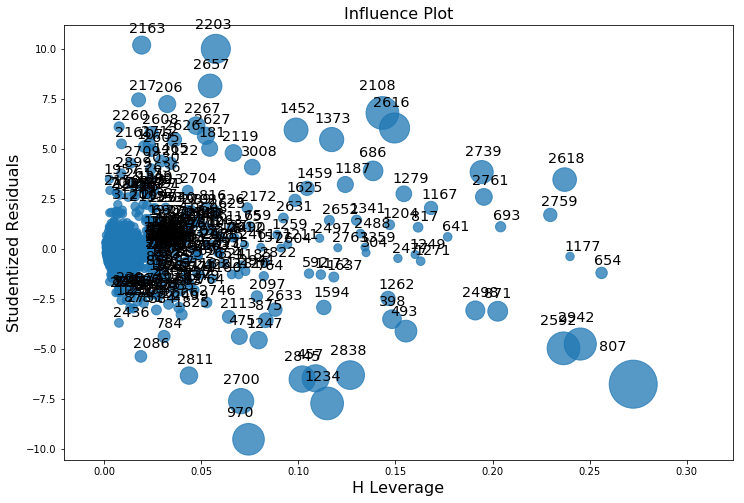

```python
# Plot Outliers
fig, ax = plt.subplots(figsize=(12,8))
fig = sm.graphics.influence_plot(global_ols_rerun, ax= ax, criterion="cooks")
```

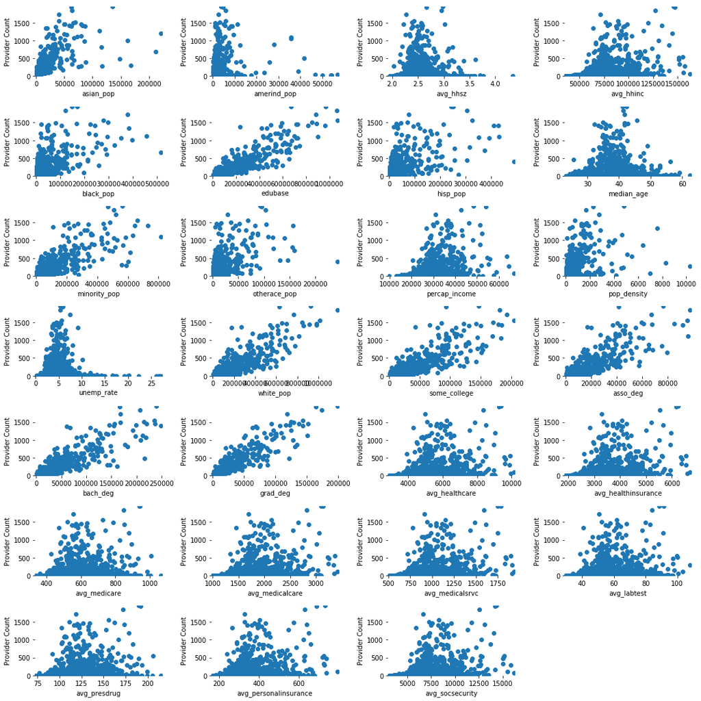

```python
# Check Linearity - Plot predictors with response
states = global_df.columns[:-3]
fig = plt.figure(figsize=(15, 15))
for sp in range(0,27):
    ax = fig.add_subplot(7,4,sp+1)
#     provType = unique_df[unique_df['state']==states[sp]]['provider_type'].value_counts().reset_index()
#     ax.scatter(test_newcounty_df.iloc[:,2], test_newcounty_df.loc[:,states[sp]])
    ax.scatter(global_df.loc[:,states[sp]], global_df.iloc[:,-1])
    ax.set_xlabel(states[sp])
    ax.set_ylabel('Provider Count')
#     ax.set_ylim(0,provType.iloc[0,1])
    plt.xticks(rotation=0)
    for key, spine in ax.spines.items():
        spine.set_visible(False)
    ax.margins(0.01, 0)
plt.tight_layout() # automatically adjusts layout to fit long labels
plt.show()
```

### Feature Selection and Importance

Our regression model results showed only few predictors that were statistically significant in predicting provider count. Feature selection is used to select those features in data that contribute most to the response variable. Having irrelevant features in the data can decrease the accuracy of many models, especially linear algorithms. To identify which predictors play a key role and remove predictors that are not statistically significant, we can use various feature selection techniques.

Greedy algorithms like Stepwise Regression and Recursive Feature Elimination (RFE) work by adding or removing attributes one at a time and building a model on those attributes that remain. RFE algorithm recursively removes attributes and uses accuracy metric to rank the feature according to their importance.

Regularization methods like Lasso and ElasticNet seek to minimize the complexity (magnitude and number of regression coefficients) of the model by penalizing a feature given a coefficient threshold.

- LASSO penalizes the sum of absolute value of regression coefficients thereby forcing many coefficients to 0.
- ElasticNet combines the properties of both LASSO and Ridge regression. It penalizes the model by using both the L2-norm (sum of squared values of coefficients) and the L1-norm (sum of absolute value of coefficients) thereby shrinking some coefficients closer to 0 to reduce variance and making other coefficients 0.

Feature importance techniques like Random Forest are used to select features using a trained supervised classifier. Random forest consists of a number of decision trees where each node in a tree is a condition on a single feature, designed to split the dataset.

```python
# Create prdictor and response variables
train_x_global = train_x_rerun
train_y_global = train_y_rerun
train_x_global.head()
```

|  | asian_pop | amerind_pop | avg_hhsz | avg_hhinc | black_pop | edubase | hisp_pop | median_age | minority_pop | otherace_pop | percap_income | pop_density | unemp_rate | white_pop | some_college | asso_deg | bach_deg | grad_deg | avg_healthcare | avg_healthinsurance | avg_medicare | avg_medicalcare | avg_medicalsrvc | avg_labtest | avg_presdrug | avg_personalinsurance | avg_socsecurity |
| --- | --- | --- | --- | --- | --- | --- | --- | --- | --- | --- | --- | --- | --- | --- | --- | --- | --- | --- | --- | --- | --- | --- | --- | --- | --- | --- | --- |
| 1249 | 135762 | 3725 | 2.98 | 145668 | 168075 | 966722 | 242411 | 42.4 | 564546 | 93346 | 48459 | 4805.5 | 5.4 | 926489 | 146621 | 76632 | 239124 | 198145 | 9378.63 | 6234.59 | 941.09 | 3144.04 | 1787.46 | 91.54 | 189.67 | 730.00 | 14346.36 |
| 1279 | 62160 | 4721 | 2.67 | 146887 | 148832 | 673227 | 250091 | 41.2 | 467666 | 94797 | 54087 | 2269.6 | 5.9 | 629703 | 93481 | 41665 | 165761 | 164681 | 9276.07 | 6168.19 | 938.77 | 3107.89 | 1747.84 | 88.53 | 192.06 | 687.83 | 14194.42 |
| 1271 | 63150 | 5873 | 2.95 | 127434 | 121952 | 1060001 | 305129 | 41.3 | 507258 | 103330 | 42729 | 1660.4 | 5.3 | 1175867 | 181490 | 97865 | 207071 | 173811 | 8357.34 | 5537.92 | 848.71 | 2819.42 | 1593.74 | 84.12 | 172.25 | 629.87 | 12508.96 |
| 1452 | 40682 | 2559 | 2.27 | 71154 | 377951 | 883391 | 76805 | 41.7 | 518776 | 28746 | 31021 | 2735.5 | 7.5 | 767399 | 193448 | 67178 | 167692 | 118665 | 4975.69 | 3277.10 | 557.11 | 1698.59 | 914.04 | 50.57 | 118.44 | 328.39 | 6670.75 |
| 2761 | 39780 | 6004 | 2.42 | 89020 | 276839 | 1065922 | 325946 | 45.7 | 660665 | 68419 | 36700 | 733.5 | 5.7 | 1013016 | 204219 | 95745 | 235845 | 143011 | 6216.44 | 4079.69 | 727.70 | 2136.76 | 1149.08 | 61.82 | 155.60 | 405.46 | 8330.19 |

```python
# Import Libraries
from sklearn.preprocessing import StandardScaler
from sklearn.model_selection import KFold
from sklearn.model_selection import cross_val_score
from sklearn.linear_model import Lasso
from sklearn.linear_model import ElasticNet
from sklearn.pipeline import Pipeline
from sklearn.metrics import mean_squared_error
from sklearn.ensemble import RandomForestRegressor
from sklearn.feature_selection import RFECV
from sklearn.linear_model import LinearRegression
```

#### Run Feature Selection Algorithms

```python
# Test options and evaluation metric
num_folds = 5
seed = 7
scoring ='neg_mean_squared_error'
```

```python
# Create Pipeline and Standardize the dataset
clf = LinearRegression()
pipelines = []
pipelines.append(('ScaledLASSO', Pipeline([('Scaler', StandardScaler()),('LASSO',Lasso())])))
pipelines.append(('ScaledEN', Pipeline([('Scaler', StandardScaler()),('EN',ElasticNet())])))
pipelines.append(('ScaledRFECV', Pipeline([('Scaler', StandardScaler()),('RFECV',RFECV(estimator=clf, cv=5))])))
pipelines.append(('ScaledRF', Pipeline([('Scaler', StandardScaler()),('RF',RandomForestRegressor(n_estimators = 100))])))
```

```python
# Run models
import math
results = []
names = []
for name, model in pipelines:
    kfold = KFold(n_splits=num_folds, random_state=seed)
    cv_results = cross_val_score(model, train_x_global, train_y_global, cv=kfold, scoring=scoring)
    results.append(cv_results)
    names.append(name)
    msg = "%s: %f (%f)" % (name, math.sqrt(abs(cv_results.mean())), cv_results.std())
    print(msg)
#     print("RMSE: %.3f" % (math.sqrt(abs(cv_results.mean()))))
```

```
ScaledLASSO: 143.782243 (40429.468955)
ScaledEN: 150.043749 (43777.646315)
ScaledRFECV: 144.261668 (40607.374926)
ScaledRF: 200.290756 (79471.382668)
```

From the results above, Lasso seems to be the most promising with lowest RMSE. Let's explore Lasso to see which variables are selected by this model.